# 16 Support vector machine

SVM (support vector machine)은 feature space에 형성된 hyperplane을 이용하여 클래스를 구분하는 방법이다.

### 16.0.1 Hyperplane

$p$-dimensional space에서 $p-1$-dimension을 가지는 편평한 affine subspace를 hyperplane이라 한다.

수학적으로 hyperplane의 식은 다음과 같다.

$$\beta_0 + \beta_1 X_1 + \beta_2 X_2 + \cdots + \beta_p X_p = 0$$

예를 들어 $p=2$인 공간에서 hyperplane은 직선이다.

만약 $\beta_0=0$이면 hyperplane은 원점을 지나고, 그렇지 않으면 지나지 않는다.

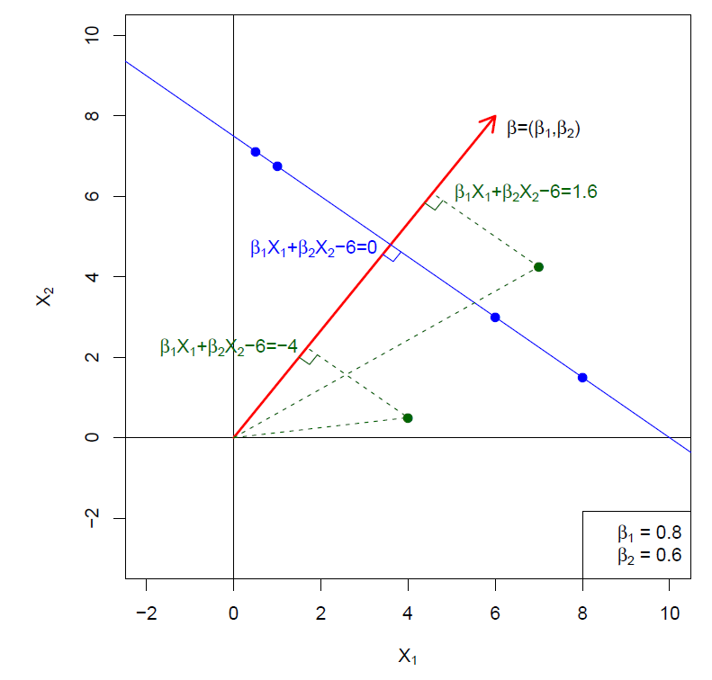

$f(X) = \beta_0 + \beta_1 X_1 + \cdots + \beta_p X_p$라고 하면, $f(X)>0$은 hyperplane의 한쪽을 $f(X)<0$는 다른 한쪽을 나타낸다.

아래 그림의 왼쪽에서 파란 포인트들과 빨간 포인트를 구분하는 hyperplane은 다양한 가능성이 있음을 나타낸다.

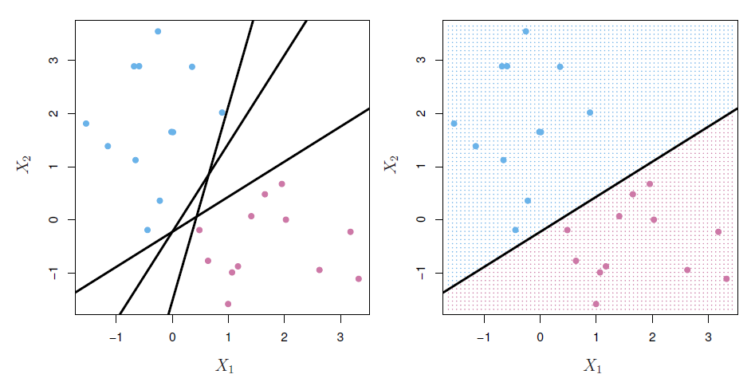

위 그림에서 $Y_i=1$인 포인트들을 파란색, $Y_i=-1$인 포인트들을 빨간색이라고 할 때, 만약 모든 $i$에 대해 $Y_i \cdot f(X_i) > 0$이라면, $ f(X) = 0$이 separating hyperplane을 정의한다고 말한다.

즉, separting hyperplane은 다음을 만족한다.

$$\beta_0 + \beta_1 x_{i1} + \beta_2 x_{i2} + \cdots + \beta_p x_{ip} > 0 \text{ if } y_i = 1,$$
$$\beta_0 + \beta_1 x_{i1} + \beta_2 x_{i2} + \cdots + \beta_p x_{ip} < 0 \text{ if } y_i = -1$$

혹은 다음과 같이 나타낼 수 있다.

$$y_i (\beta_0 + \beta_1 x_{i1} + \beta_2 x_{i2} + \cdots + \beta_p x_{ip}) > 0 \text{ for all } i = 1, \cdots, n.$$

### 16.0.2 Maximal margin classifier

가능한 separating hyperplane 중에서 가장 큰 gap (margin)을 형성하는 hyperplane을 maximal margin classifier라고 한다.

Margin은 hyperplane과 각 관찰값들의 거리 중 최소값을 말한다.

Maximal margin classifier (optimal separting classifier)는 간단하면서도 훌륭한 classifier지만 항상 만들 수 있는 것은 아니다.

Maximal margin classifier를 찾는 문제는 다음의 최적화 문제와 동일하다.

$$\underset{\boldsymbol{\beta}}{\mathrm{maximize}}~ M \text{ subject to }$$
$$\sum_{j=1}^{p} \beta_j^2 = 1,$$
$$y_i (\beta_0 + \beta_1 x_{i1} + \beta_2 x_{i2} + \cdots + \beta_p x_{ip}) \geq M \text{ for all } i=1, \cdots, N.$$

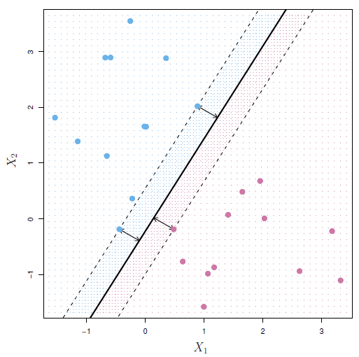

만약 $\beta_0 + \beta_1 x_{1} + \beta_2 x_{2} + \cdots + \beta_p x_{p}=0$이 어떤 hyperplane을 형성한다면 임의의 $k$에 대해 $k(\beta_0 + \beta_1 x_{1} + \beta_2 x_{2} + \cdots + \beta_p x_{p})=0$ 또한 동일한 hyperplane을 형성한다.

$\sum_{j=1}^{p} \beta_j^2 = 1$의 조건은 무수한 hyperplane 식 중 하나의 식을 특정할 수 있게 한다. $||\beta||=1$이라고 표현하기도 함.

이렇게 특정된 $\beta$들은 다음을 만족하게 한다.

$$\text{distance from } i\text{-th observation to hyperplane} = y_i(\beta_0 + \beta_1 x_{i1} + \beta_2 x_{i2} + \cdots + \beta_p x_{ip})$$

한편, 위의 조건

$$y_i (\beta_0 + \beta_1 x_{i1} + \beta_2 x_{i2} + \cdots + \beta_p x_{ip}) \geq M \text{ for all } i=1, \cdots, N$$

는 다음과 같이 간단히 표현하기도 한다.

$$y_i (x_i^{\top}\beta + \beta_0) \geq M \text{ for all } i=1, \cdots, N$$

### 16.0.3 Optimal Separating Hyperplanes

위 optimization 문제를 더 자세히 보자.

$|| \beta || = 1$는 $x_i^{\top}\beta + \beta_0$의 식을 normalize하여 제약 조건을 다음과 같이 바꾸어 표현하여 제외할 수 있다.

$$\frac{1}{||\beta||} y_i (x_i^{\top}\beta + \beta_0) \geq M \text{ for all } i=1, \cdots, N$$

혹은

$$y_i (x_i^{\top}\beta + \beta_0) \geq M ||\beta|| \text{ for all } i=1, \cdots, N$$

위 조건은 임의로 scale된 $\beta, \beta_0$의 조합에 대해 성립해야 하기 때문에, 편의상 $||\beta|| = 1/M$이라고 하겠다.

따라서, 위 제약조건을 재정리하면,

$$\underset{\beta, \beta_0}{\mathrm{min}}~ \frac{1}{2} ||\beta||^2$$
$$\text{subject to }y_i (x_i^{\top}\beta + \beta_0 ) \geq 1 \text{ for all } i=1, \cdots, N.$$

위 셋팅에서는 margin의 두께가 $1/||\beta||$이며, $\beta$와 $\beta_0$를 적절히 선택하여 두께를 최대화하고자 한다.

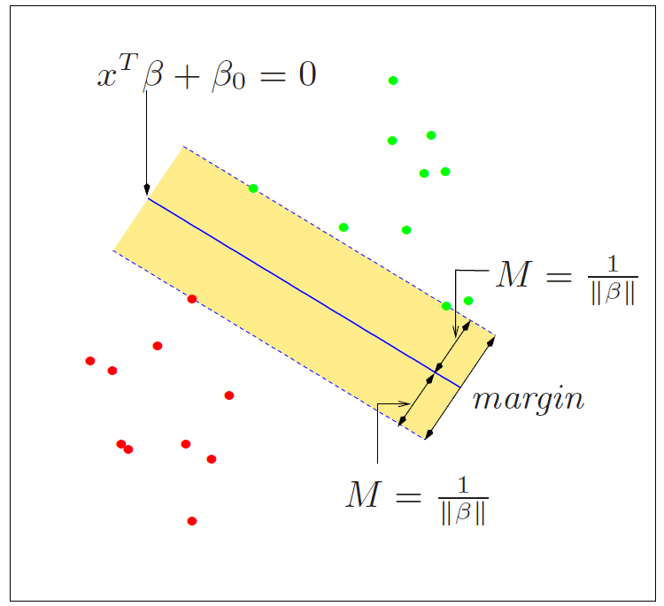

```python
import matplotlib.pyplot as plt
import numpy as np
x1 = (1,1)
x2 = (4,4)
plt.plot(x1[0], x1[1], 'bo')
plt.plot(x2[0], x2[1], 'ro')

beta0, beta1, beta2 = 5, -2, -1
xs = np.linspace(1,4,100)
ys = (-beta0 - beta1*xs) / beta2

plt.plot(xs, ys)
plt.show()
```

[figure not shown]

```python
M1 = (beta0 + beta1 * x1[0] + beta2 * x1[1]) / np.sqrt(beta1**2 + beta2**2)
M2 = (beta0 + beta1 * x2[0] + beta2 * x2[1]) / np.sqrt(beta1**2 + beta2**2)
(M1, M2)
```

```
(0.8944271909999159, -3.1304951684997055)
```

```python
M = min(abs(M1), abs(M2))
M
```

```
0.8944271909999159
```

```python
norm_beta = np.sqrt(beta1**2 + beta2**2)
norm_beta
```

```
2.23606797749979
```

```python
c = norm_beta * M
c
```

```
2.0
```

```python
# reparmetrization. calculate distance
new_beta0, new_beta1, new_beta2  = beta0 / c, beta1 / c, beta2 / c

(new_beta0 + new_beta1 * x1[0] + new_beta2 * x1[1]) / np.sqrt(new_beta1**2 + new_beta2**2)
```

```
0.8944271909999159
```

```python
# under reparameterization : 1 / ||beta|| = M
1 / np.sqrt(new_beta1**2 + new_beta2**2)
```

```
0.8944271909999159
```

```python
new_beta0 + new_beta1 * x1[0] + new_beta2 * x1[1]
```

```
1.0
```

```python
new_beta0 + new_beta1 * x2[0] + new_beta2 * x2[1]
```

```
-3.5
```

### 16.0.4 Duality principle

수학적 최적화 이론에서 duality란 최적화 문제를 primal problem과 또는 dual problem의 두 관점에서 볼 수 있다는 것이다.

이를 duality 혹은 duality principle 이라고 부른다.

Duality theorem을 바탕으로 primal 문제와 dual 문제는 서로 연결되어 있다.

다음의 primal 문제를 보자.

$$\min_{x} f(x) \text{ subject to } g_i(x) \leq 0, \enspace i=1, \cdots, m$$

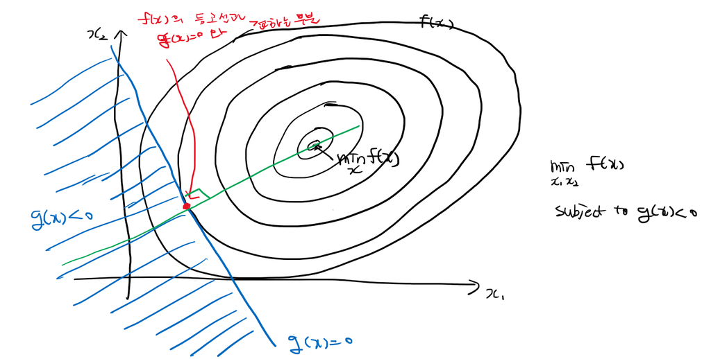

다음의 dual problem으로 바꾸어 생각할 수 있으며, Lagrangian dual problem이라 한다.

$$\max_{u} \inf_{x} \left( f(x) + \sum_{i=1}^m u_i g_i (x) \right) \text{ subject to } u_i \geq 0, \enspace i=1,\cdots,m.$$

여기서 $f, g_i$는 convex이고, continuoulsy differentiable 함수들이다.

또한 다음의 Wolfe dual problem으로 바꾸어 생각할 수도 있다. (SVM)

$$\max_{x,u} f(x) + \sum_{i=1}^m u_j g_j (x)$$
$$\text{ subject to } \nabla f(x) + \sum_{i=1}^{m} u_i \nabla g_i(x) = 0, \enspace u_i \geq 0, \enspace i=1,\cdots,m.$$

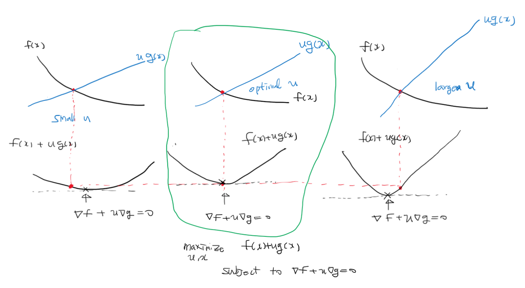

Dual problem을 통해 찾은 최적해는 항상 primal problem의 최적해보다 같거나 작은데,

특정 조건을 만족하면 dual problem의 해와 primal problem의 해가 일치한다. 이를 strong duality라고 한다.

Optimal separating hyperplane의 문제를 Wolfe duality 관점에서 보면, objective function인 Lagrangian은

$$\frac{1}{2}||\beta||^2 - \sum_{i=1}^{N} \alpha_i[y_i (x_i^{\top}\beta + \beta_0) - 1]$$

이고, Wolfe dual problem의 제약조건에 따라

$$\frac{1}{2}\nabla_{\beta, \beta_0} ||\beta||^2 - \sum_{i=1}^{N} \alpha_i \nabla_{\beta, \beta_0} [y_i (x_i^{\top}\beta + \beta_0) - 1] = 0$$

이어야 한다. 정리하면,

$$\beta - \sum_{i=1}^{N} \alpha_i y_i x_i = 0 \enspace\text{ by parital derivative w.r.t. }\beta$$
$$\sum_{i=1}^{N} \alpha_i y_i = 0 \enspace\text{ by parital derivative w.r.t. }\beta_0$$

이 되는데 이를 다시 objective function에 대입하면, Wolfe dual function을 다음과 같이 정리할 수 있다.

$$L_D = \sum_{i=1}^{N} \alpha_i - \frac{1}{2} \sum_{i=1}^{N} \sum_{k=1}^{N} \alpha_i \alpha_k y_i y_k x_i^{\top} x_k$$

Wolfe dual problem은

$$\max_{\alpha} L_D$$
$$\text{subject to } \alpha_i \geq 0, \sum_{i=1}^{N} \alpha_i y_i =0.$$

더 나아가, 해는 Karush-Kuhn-Tucker (KKT) 조건을 만족해야 하는데, 이는 위에서 찾은 식들과 더불어, 다음과 같다.

$$\beta = \sum_{i=1}^{N} \alpha_i y_i x_i$$
$$\sum_{i=1}^{N} \alpha_i y_i = 0$$
$$\alpha_i \geq 0$$
$$\alpha_i [y_i (x_i^{\top} \beta + \beta_0) - 1] = 0, \text{ for all } i.$$

마지막 식은 complementary slackness 라고도 불리우며, 이를 통해 다음을 알 수 있다.

1. 만약 $\alpha_i > 0$이면, $y_i (x_i^{\top} \beta + \beta_0) = 1$이다. 즉 $x_i$는 boundary에 있다.
2. 만약 $y_i (x_i^{\top} \beta + \beta_0) > 1$이면, $x_i$는 boundary에 있지 않고, $\alpha_i = 0$이다.

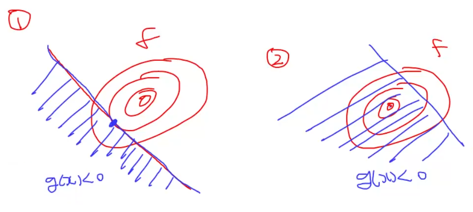

### 16.0.5 Non-separable case

위의 maximal margin classifier는 이상적이지만, data가 speparable하지 않은 경우들이 더 많다.

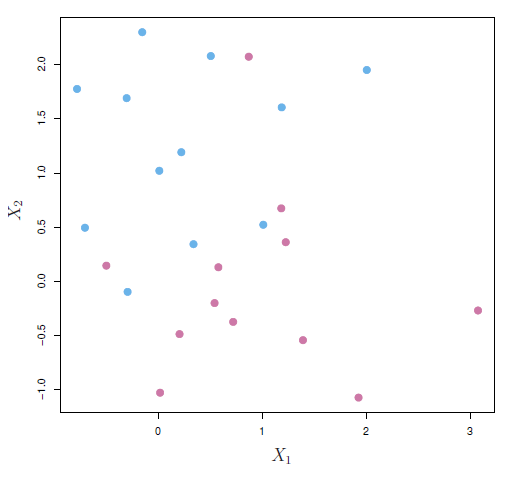

또한 separable하더라도 noisy한 데이터의 경우 maximal margin classifier를 적용하기 어렵다.

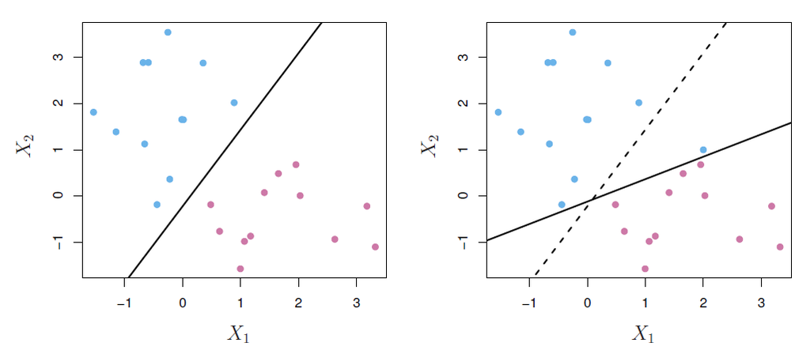

Support vector classifier는 soft margin을 최대화한다.

### 16.0.6 Support vector classifier

Support vector classifier는 다음의 문제를 최적화 한다.

$$\underset{\boldsymbol{\beta, \xi}}{\mathrm{maximize}}~M \text{ subject to }\sum_{j=1}^{p} \beta_j^2 = 1,$$
$$y_i (\beta_0 + \beta_1 x_{i1} + \beta_2 x_{i2} + \cdots + \beta_b x_{ip}) \geq M(1-\xi_i),$$
$$\xi_i \geq 0, \enspace \sum_{i=1}^{N} \xi_i \leq C.$$

여기서 $C$는 nonnegative tunning parameter이다.

$\xi_1, \cdots, \xi_n$은 slack variable로 각 관찰값이 margin이나 hyperplane의 반대편에 있는 것이 가능하게 한다.

- $\xi_i = 0$이라는 것은 $i$-th 관찰값이 올바른 사이드에 있다는 것이다.
- $\xi_i > 0$이라는 것은 $i$-th 관찰값이 margin을 넘어선 곳에 있다는 것이다.
- $\xi_i > 1$이라는 것은 $i$-th 관찰값이 아예 hyperplane조차 넘어서 반대편에 있다는 것이다.

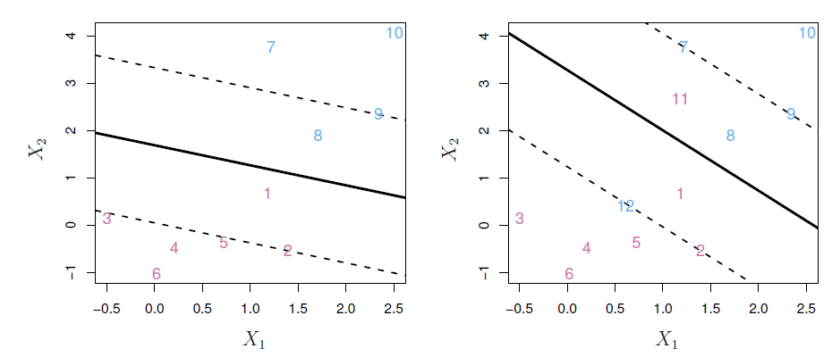

$$\min~||\beta||$$
$$\text{ subject to } y_i (x_i^{\top}\beta + \beta_0) \geq (1-\xi_i),$$
$$\xi_i \geq 0, \enspace \sum_{i=1}^{N} \xi_i \leq C.$$

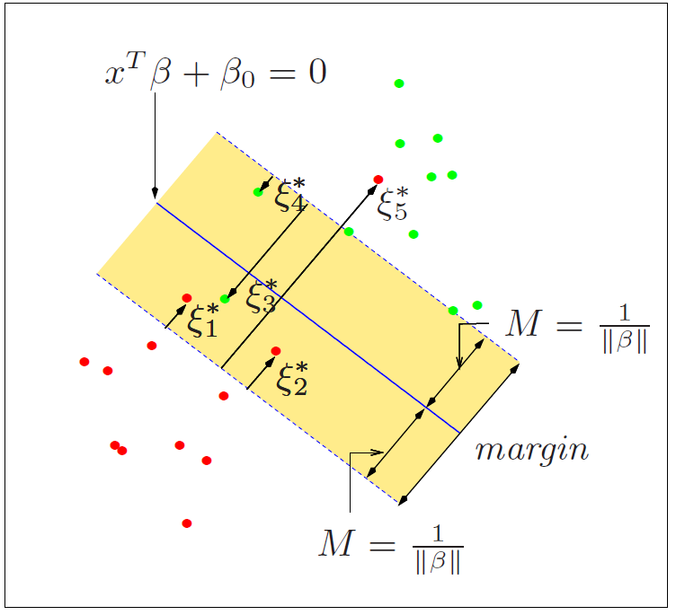

$C$는 $\xi$들의 합계를 제한하는 boundary로서, margin을 침범하는 총량을 나타낸다고 볼 수 있다.

만약 $C=0$이라면 어떠한 침범도 허용되지 않으며, maximal margin hyperplane의 경우이다.

$C>0$에 대해, $C$보다 적은 개수의 관찰값들만이 hyperplane의 반대편에 놓인다.

$C$가 커질수록, violation에 대한 tolerance가 커지며, margin 또한 증가한다.

실전에서는 $C$의 값은 cross-validation 등의 방법을 통해 결정한다.

위 최적화 문제의 흥미로운 점은, hyperplane을 결정하는 것은 margin이나 hyperplane을 침범한 관찰값들이며, margin 바깥에 있는 올바른 관찰값들은 hyperplane의 결정에 아무런 영향을 미치지 않는다.

Margin의 안쪽이나, hyperplane의 반대편에 놓인 관찰값들을 support vector라고 한다.

$C$가 크면 많은 support vector들이 classifer를 결정하는데 이용되며, 적은 variance를 갖는다.

$C$가 작으면 적은 support vector들이 classifer를 결정하는데 이용되며, 적은 bias를 지닌다.

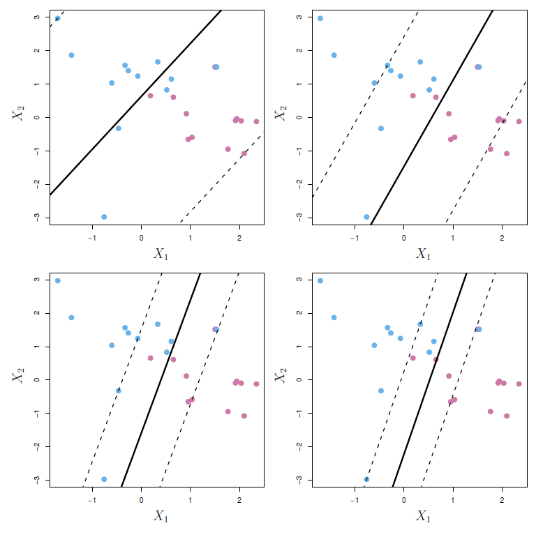

Support vector classifier가 hyperplane으로부터 멀리 떨어진 값들의 영향을 받지 않는다는 점은 장점으로 적용될 수 있다.

LDA 같은 경우, 전체 관찰값들의 평균을 이용하기 때문에, 멀리 떨어진 값들의 영향을 받는다.

Logistic regression의 경우 support vector classifier와 비슷하게 멀리 떨어진 값들의 영향을 적게 받는다.

### 16.0.7 Computing the support vector classifier

예전에 했던 것과 비슷하게, Wolfe duality 문제로 표현 가능하다.

즉,

$$\min_{\beta, \beta_0} \frac{1}{2} || \beta ||^2 + C' \sum_{i=1}^{N} \xi_i$$
$$\text{subject to } \xi_i \geq 0, \enspace y_i (x_i^{\top}\beta + \beta_0) \geq (1-\xi_i) \text{ for all }i.$$

- $C'$이 크면 $C' \sum_{i=1}^{N} \xi_i$를 작게하기 위해, margin을 침범하는 관찰값이 적도록 최대한 노력하겠다는 뜻이다.
  - $C' = \infty$가 완전히 seprable 되는 케이스에 해당한다. 모든 $\xi$가 0이 되어야 하기 때문.
- $C'$이 작으면 $C' \sum_{i=1}^{N} \xi_i$ 항 보다는 상대적으로 $\frac{1}{2} || \beta ||^2$를 최소화하기 위해 노력할 것이다.

이제 위 문제를 Wolfe dual problem으로 바꾸어 보자.

Wolfe dual problem에서 maximize해야 할 objective function은

$$\frac{1}{2}||\beta||^2 + C' \sum_{i=1}^{N} \xi_i - \sum_{i=1}^{N} \alpha_i[y_i (x_i^{\top}\beta + \beta_0) - (1-\xi_i)] - \sum_{i=1}^{N} \mu_i \xi_i$$

이고, Wolfe dual problem의 제약조건에 따라

$$\nabla_{\beta_0, \beta, \xi} \left(\frac{1}{2}||\beta||^2 + C' \sum_{i=1}^{N} \xi_i - \sum_{i=1}^{N} \alpha_i[y_i (x_i^{\top}\beta + \beta_0) - (1-\xi_i)] - \sum_{i=1}^{N} \mu_i \xi_i \right)= 0$$

이어야 한다. 정리하면,

$$\beta = \sum_{i=1}^{N} \alpha_i y_i x_i$$
$$0 = \sum_{i=1}^{N} \alpha_i y_i$$
$$\alpha_i = C' - \mu_i$$
$$\alpha_i, \mu_i, \xi_i \geq 0$$

이며, 이를 다시 objective function에 대입하여,

$$L_D = \sum_{i=1}^{N} \alpha_i - \frac{1}{2} \sum_{i=1}^{N} \sum_{i'=1}^{N} \alpha_i \alpha_{i'} y_i y_{i'} x_i^{\top} x_{i'}$$

이고, Wolfe duality problem은

$$\max_{\alpha} L_D$$

$$\text{subject to } 0 \leq \alpha_i \leq C' \text{ (dual feasibility) },$$
$$\sum_{i=1}^{N} \alpha_i y_i = 0 \text{ (Lagrange stability)},$$
$$\alpha_i [y_i (x_i^{\top} \beta + \beta_0 ) - (1-\xi_i)] = 0,$$
$$\mu_i \xi_i = 0,$$
$$y_i (x_i^{\top} \beta + \beta_0) - (1 - \xi_i) \geq 0.$$

마지막 조건들을 KKT condition이라고도 부른다.

위 최적화 문제를 풀어 $\hat \alpha$를 찾으면,
$$\hat \beta = \sum_{i=1}^{N} \hat \alpha_i y_i x_i$$
로 $\beta$의 해를 찾을 수 있다.

서포트벡트들에 대해서만 $\hat \alpha_i$가 0이 아님을 상기하자.

#### 16.0.7.1 조건들의 의미

위 조건은 $\alpha_i=0$ 혹은 $[y_i (x_i^{\top} \beta + \beta_0 ) - (1-\xi_i)] = 0$을 의미한다.

$i$-th 관찰값 $x_i$가 올바른 사이드에 있는 경우, $\alpha_i = 0$.

$i$-th 관찰값 $x_i$가 margin을 침범하여 있는 경우 (서포트벡터), $[y_i (x_i^{\top} \beta + \beta_0 ) - (1-\xi_i)] = 0$이고 $\alpha_i > 0$.

- $\mu_i \xi_i = 0$

위 조건은 $\mu_i = 0$ 혹은 $\xi_i = 0$

$i$-th 관찰값 $x_i$가 올바른 사이드에 있는 경우, $\xi_i = 0$.

$i$-th 관찰값 $x_i$가 margin을 침범하여 있는 경우, $\mu_i = 0$.

### 16.0.8 Nonlinear boundary

Feature space를 $X^2, X^3$등으로 확장하는 방법이 있다.

예를 들어, $(X_1, X_2)$ 대신 feature space를 $(X_1, X_2, X_1^2, X_2^2, X_1 X_2)$로 확장하여 사용하는 경우, decision boundary는

$$\beta_0 + \beta_1 X_1 + \beta_2 X_2 + \beta_3 X_1^2 + \beta_4 X_2^2 + \beta_5 X_1 X_2 = 0$$

의 형태를 지닌다.

또한 예를 들어, $X_1, X_2, \cdots, X_p$의 feature가 있을 때, 이를

$$X_1, X_1^2, X_2, X_2^2, \cdots, X_p, X_p^2$$

의 공간으로 확장하여 사용하면, 최적화 문제는 다음과 같다.

$$\underset{\boldsymbol{\beta, \xi}}{\mathrm{maximize}}~M$$
$$\text{ subject to } y_i \left(\beta_0 + \sum_{j=1}^p \beta_{j1}x_{ij} + \sum_{j=1}^{p}\beta_{j2} x_{ij}^2 \right) \geq M(1-\xi_i),$$
$$\xi_i \geq 0, \enspace \sum_{i=1}^{n} \xi_i \leq C, \enspace \sum_{j=1}^{p}\sum_{k=1}^{2} \beta_{jk}^2 = 1.$$

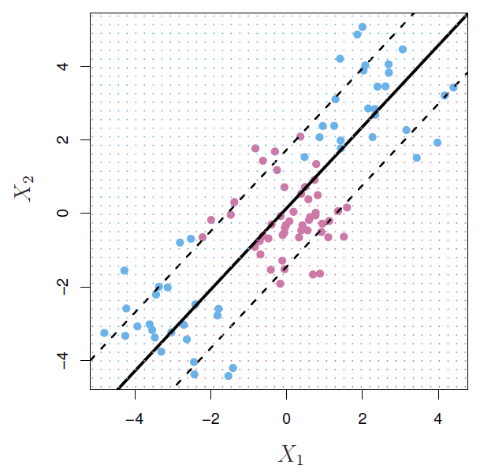

### 16.0.9 Support vector machine

Support vector machine (SVM)은 kernel을 이용하여, support vector classifier의 개념을 확장된 feature space에 적용하는 것이다.

커널을 이용하여 nonlinear boundary에 대해 classifier를 적용하고자 한다.

$$\beta = \sum_{i=1}^{N} \alpha_i y_i x_i$$

이므로, linear support vector classifier는 다음과 같이 나타낼 수 있다.

$$f(x) = \beta_0 + \langle \beta, x \rangle = \beta_0 + \sum_{i=1}^{n} \alpha_i y_i \langle x, x_i \rangle$$

서포트벡터들에 대해서만 $\alpha_i$가 0이 아님을 상기하면 다음과 같이 나타낼 수도 있다.

$$f(x) = \beta_0 + \langle \beta, x \rangle = \beta_0 + \sum_{i \in S} \alpha_i y_i \langle x, x_i \rangle$$

여기서 $S$는 서포트 포인트들의 모임이다.

비선형적인 경계선을 표현하기 위해 $\langle x, x_i \rangle$ 대신 보다 flexible한, 변환된 특성 벡터에 대한 식을 이용할 수 있다.

즉, 해 함수는 어떤 함수 $h$를 이용하여,

$$f(x) = \beta_0 + \sum_{i \in S} \alpha_i y_i \langle h(x), h(x_i) \rangle$$

보다 유연한 상황에 적용할 수 있다.

Wolfe dual function인 Lagrangian은 다음의 형식을 지닌다.

$$L_D = \sum_{i=1}^{N} \alpha_i - \frac{1}{2} \sum_{i=1}^{N} \sum_{i'=1}^{N} \alpha_i \alpha_{i'} y_i y_{i'} \langle h(x_i), h(x_{i'}) \rangle$$

#### 16.0.9.1 SVM kernel example

왼쪽은 3차 다항식 커널이 적용된 SVM이다.

오른쪽은 radial 커널이 적용된 SVM이다.

이 예제에서는 어느 커널이든 결정 경계를 캡처할 수 있는 것으로 보인다.

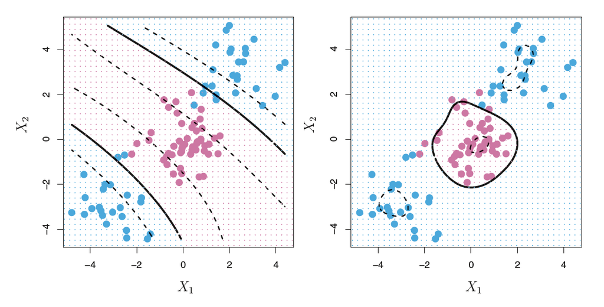

### 16.0.10 SVMs with more than two classes

#### 16.0.10.1 One-versus-one classification

$K>2$개의 클래스가 있을 때, one-versus-one 방법에서는 임의의 $k$ 클래스와 $k'$ 클래스를 비교하는 총 $\binom{K}{2}$개의 SVM을 생성하는 것이 가능하다.

새로운 test observation에 대해 $\binom{K}{2}$개의 모든 SVM으로 prediction을 진행하여 가장 많이 할당된 클래스를 prediction value로 정한다.

#### 16.0.10.2 One-versus-all classification

$K>2$개의 클래스가 있을 때, one-versus-all 방법에서는 $k$ 클래스와 나머지 클래스 간의 비교를 진행하는 총 $K$개의 SVM을 생성한다.

$\beta_{0k}, \beta_{1k}, \cdots, \beta_{pk}$를 $k$ 클래스와 나머지를 구분하는 SVM의 paramter라고 하면,

새로운 관찰값 $x^{*}$의 prediction 클래스는 $\beta_{0k} + \beta_{1k}x_1^{*} + \beta_{2k}x_2^{*} + \cdots + \beta_{pk}x_{p}^{*}$를 가장 큰 값으로 하는 $k$를 prediction 클래스로 한다.

### 16.0.11 Scikit-learn에서의 SVM

```python
import numpy as np
from sklearn import datasets
from sklearn.pipeline import Pipeline
from sklearn.preprocessing import StandardScaler
from sklearn.svm import LinearSVC
from sklearn.svm import SVC
from sklearn.metrics import accuracy_score
from sklearn.model_selection import train_test_split
from sklearn.metrics import classification_report
```

사이킷런의 SVM 모델에서는 C 파라미터를 사용해 마진의 크기를 조절한다.

C 값이 작으면 마진의 크기가 커지며, C 값이 크면 마진이 좁아진다.

#### 16.0.11.1 simple example

```python
x1 = (1,1)
x2 = (2,4)
```

```python
svm_simple = LinearSVC(C=100)
svm_simple.fit([x1, x2], [-1, 1])
```

```
LinearSVC(C=100)
```

```python
svm_simple.intercept_, svm_simple.coef_
```

```
(array([-1.2747401]), array([[-0.56620593,  0.8508624 ]]))
```

```python
import matplotlib.pyplot as plt
plt.figure(figsize=(6, 6))

plt.plot(x1[0], x1[1], 'bo')
plt.plot(x2[0], x2[1], 'ro')


w = svm_simple.coef_[0]
a = - w[0] / w[1]
b = - (svm_simple.intercept_[0]) / w[1]

xx = np.linspace(-1,5,100)
yy = a * xx + b

margin = 1 / np.sqrt(np.sum(svm_simple.coef_ ** 2))
yy_down = yy - np.sqrt(1 + a ** 2) * margin
yy_up = yy + np.sqrt(1 + a ** 2) * margin

plt.plot(xx, yy)

plt.plot(xx, yy_down, "k--")
plt.plot(xx, yy_up, "k--")

plt.show()
```

[figure not shown]

#### 16.0.11.2 simple example 2

```python
x1 = (1,1)
x2 = (2,4)
x3 = (3,5)
```

```python
svm_simple2 = SVC(C=100, kernel='linear')
svm_simple2.fit([x1, x2, x3], [-1, 1, 1])
```

```
SVC(C=100, kernel='linear')
```

```python
svm_simple2.intercept_, svm_simple2.coef_, svm_simple2.dual_coef_  # dual_coef_ = alpha
```

```
(array([-1.8]), array([[0.2, 0.6]]), array([[-0.2,  0.2]]))
```

```python
import matplotlib.pyplot as plt
plt.figure(figsize=(6, 6))

plt.plot(x1[0], x1[1], 'bo')
plt.plot(x2[0], x2[1], 'ro')
plt.plot(x3[0], x3[1], 'ro')


w = svm_simple2.coef_[0]
a = - w[0] / w[1]
b = - (svm_simple2.intercept_[0]) / w[1]

xx = np.linspace(-1,5,100)
yy = a * xx + b

margin = 1 / np.sqrt(np.sum(svm_simple2.coef_ ** 2))
yy_down = yy - np.sqrt(1 + a ** 2) * margin
yy_up = yy + np.sqrt(1 + a ** 2) * margin

plt.plot(xx, yy)

plt.plot(xx, yy_down, "k--")
plt.plot(xx, yy_up, "k--")

plt.show()
```

[figure not shown]

#### 16.0.11.3 wine data example

```python
raw_wine = datasets.load_wine()
X = raw_wine.data
y = raw_wine.target
```

```python
y
```

```
array([0, 0, 0, 0, 0, 0, 0, 0, 0, 0, 0, 0, 0, 0, 0, 0, 0, 0, 0, 0, 0, 0,
       0, 0, 0, 0, 0, 0, 0, 0, 0, 0, 0, 0, 0, 0, 0, 0, 0, 0, 0, 0, 0, 0,
       0, 0, 0, 0, 0, 0, 0, 0, 0, 0, 0, 0, 0, 0, 0, 1, 1, 1, 1, 1, 1, 1,
       1, 1, 1, 1, 1, 1, 1, 1, 1, 1, 1, 1, 1, 1, 1, 1, 1, 1, 1, 1, 1, 1,
       1, 1, 1, 1, 1, 1, 1, 1, 1, 1, 1, 1, 1, 1, 1, 1, 1, 1, 1, 1, 1, 1,
       1, 1, 1, 1, 1, 1, 1, 1, 1, 1, 1, 1, 1, 1, 1, 1, 1, 1, 1, 1, 2, 2,
       2, 2, 2, 2, 2, 2, 2, 2, 2, 2, 2, 2, 2, 2, 2, 2, 2, 2, 2, 2, 2, 2,
       2, 2, 2, 2, 2, 2, 2, 2, 2, 2, 2, 2, 2, 2, 2, 2, 2, 2, 2, 2, 2, 2,
       2, 2])
```

```python
X_tn, X_te, y_tn, y_te = train_test_split(X, y)
std_scale = StandardScaler()
std_scale.fit(X_tn)
X_tn_std = std_scale.transform(X_tn)
X_te_std = std_scale.transform(X_te)
```

```python
clf_svm_lr = LinearSVC(C=0.1)
clf_svm_lr.fit(X_tn_std, y_tn)
```

```
LinearSVC(C=0.1)
```

```python
pred_svm = clf_svm_lr.predict(X_te_std)
print(pred_svm)
```

```
[1 1 1 0 1 0 2 2 1 0 0 2 0 0 1 1 0 0 2 1 1 0 2 2 1 1 2 1 1 1 1 2 1 0 0 1 1
 2 0 1 2 1 2 2 0]
```

```python
print(accuracy_score(y_te, pred_svm))
```

```
1.0
```

```python
print(classification_report(y_te, pred_svm))
```

```
              precision    recall  f1-score   support

           0       1.00      1.00      1.00        13
           1       1.00      1.00      1.00        20
           2       1.00      1.00      1.00        12

    accuracy                           1.00        45
   macro avg       1.00      1.00      1.00        45
weighted avg       1.00      1.00      1.00        45
```

### 16.0.12 iris data example

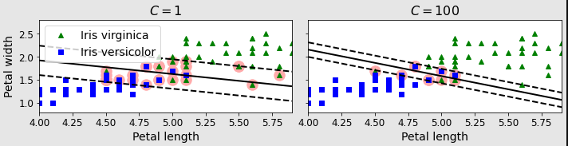

```python
iris = datasets.load_iris()
X = iris["data"][:, (2, 3)]  #  꽃잎 길이, 너비
y = (iris["target"] == 2).astype(np.float64)  # Iris-Virginica
```

```python
import pandas as pd
pd.DataFrame(np.c_[X, y], columns=("petal length", "petal_width", "target"))
```

|  | petal length | petal_width | target |
| --- | --- | --- | --- |
| 0 | 1.4 | 0.2 | 0.0 |
| 1 | 1.4 | 0.2 | 0.0 |
| 2 | 1.3 | 0.2 | 0.0 |
| 3 | 1.5 | 0.2 | 0.0 |
| 4 | 1.4 | 0.2 | 0.0 |
| ... | ... | ... | ... |
| 145 | 5.2 | 2.3 | 1.0 |
| 146 | 5.0 | 1.9 | 1.0 |
| 147 | 5.2 | 2.0 | 1.0 |
| 148 | 5.4 | 2.3 | 1.0 |
| 149 | 5.1 | 1.8 | 1.0 |

150 rows × 3 columns

```python
svm_clf = Pipeline([
    ("scaler", StandardScaler()),
    ("linear_svc", LinearSVC(C=1))
])

svm_clf.fit(X, y)
```

```
Pipeline(steps=[('scaler', StandardScaler()), ('linear_svc', LinearSVC(C=1))])
```

```python
svm_clf.predict([[5.5, 1.7]])
```

```
array([1.])
```

```python
svm_clf.named_steps['linear_svc']
```

```
LinearSVC(C=1)
```

```python
svm_clf.named_steps['linear_svc'].intercept_, svm_clf.named_steps['linear_svc'].coef_
```

```
(array([-1.9704735]), array([[1.52203773, 1.70722752]]))
```

```python
X_transform = svm_clf.named_steps['scaler'].transform(X)
```

```python
w = svm_clf.named_steps['linear_svc'].coef_[0]
a = - w[0] / w[1]

xx = np.linspace(min(X_transform[:,0]), max(X_transform[:,0]), 100)
yy = a * xx - svm_clf.named_steps['linear_svc'].intercept_ / w[1]


margin = 1 / np.sqrt(np.sum(svm_clf.named_steps['linear_svc'].coef_ ** 2))
yy_down = yy - np.sqrt(1 + a ** 2) * margin
yy_up = yy + np.sqrt(1 + a ** 2) * margin
```

```python
plt.figure(figsize=(6, 6))

plt.scatter(X_transform[y==0, 0], X_transform[y==0, 1], edgecolors="k", marker="^", color="blue", label='versicolor')
plt.scatter(X_transform[y==1, 0], X_transform[y==1, 1], edgecolors="k", marker="s", color="grey", label='virginica')

plt.plot(xx, yy)
plt.plot(xx, yy_down, "k--")
plt.plot(xx, yy_up, "k--")

plt.show()
```

[figure not shown]

```python
X = iris["data"][:, (2, 3)]  #  꽃잎 길이, 너비
y = (iris["target"] == 2).astype(np.float64)  # Iris-Virginica

svm_clf_10 = Pipeline([
    ("scaler", StandardScaler()),
    ("linear_svc", LinearSVC(C=10))
])

svm_clf_10.fit(X, y)

X_transform = svm_clf_10.named_steps['scaler'].transform(X)

w = svm_clf_10.named_steps['linear_svc'].coef_[0]
a = - w[0] / w[1]

xx = np.linspace(min(X_transform[:,0]), max(X_transform[:,0]), 100)
yy = a * xx - svm_clf_10.named_steps['linear_svc'].intercept_ / w[1]


margin = 1 / np.sqrt(np.sum(svm_clf_10.named_steps['linear_svc'].coef_ ** 2))
yy_down = yy - np.sqrt(1 + a ** 2) * margin
yy_up = yy + np.sqrt(1 + a ** 2) * margin

plt.figure(figsize=(6, 6))

plt.scatter(X_transform[y==0, 0], X_transform[y==0, 1], edgecolors="k", marker="^", color="blue", label='versicolor')
plt.scatter(X_transform[y==1, 0], X_transform[y==1, 1], edgecolors="k", marker="s", color="grey", label='virginica')

plt.plot(xx, yy)
plt.plot(xx, yy_down, "k--")
plt.plot(xx, yy_up, "k--")

plt.show()
```

[figure not shown]

#### 16.0.12.1 non-linear svm

```python
import matplotlib.pyplot as plt
```

```python
from sklearn.datasets import make_moons
X, y = make_moons(n_samples=100, noise=0.15)

def plot_dataset(X, y, axes):
    plt.plot(X[:, 0][y==0], X[:, 1][y==0], "bs")
    plt.plot(X[:, 0][y==1], X[:, 1][y==1], "g^")
    plt.axis(axes)
    plt.grid(True, which='both')
    plt.xlabel(r"$x_1$", fontsize=20)
    plt.ylabel(r"$x_2$", fontsize=20, rotation=0)

plot_dataset(X, y, [-1.5, 2.5, -1, 1.5])
plt.show()
```

[figure not shown]

```python
from sklearn.svm import SVC
polynomial_svm_clf = Pipeline([
        ("scaler", StandardScaler()),
        ("svm_clf", SVC(kernel="poly", degree=3, coef0=1, C=1))
    ])

polynomial_svm_clf.fit(X, y)
```

```
Pipeline(steps=[('scaler', StandardScaler()),
                ('svm_clf', SVC(C=1, coef0=1, kernel='poly'))])
```

```python
def plot_predictions(clf, axes):
    x0s = np.linspace(axes[0], axes[1], 100)
    x1s = np.linspace(axes[2], axes[3], 100)
    x0, x1 = np.meshgrid(x0s, x1s)
    X = np.c_[x0.ravel(), x1.ravel()]
    y_pred = clf.predict(X).reshape(x0.shape)
    y_decision = clf.decision_function(X).reshape(x0.shape)
    plt.contourf(x0, x1, y_pred, cmap=plt.cm.brg, alpha=0.2)
    plt.contourf(x0, x1, y_decision, cmap=plt.cm.brg, alpha=0.1)

plot_predictions(polynomial_svm_clf, [-1.5, 2.5, -1, 1.5])
plot_dataset(X, y, [-1.5, 2.5, -1, 1.5])

plt.show()
```

[figure not shown]

```python
## radial kernel

gamma1, gamma2 = 0.1, 5
C1, C2 = 0.001, 1000
hyperparams = (gamma1, C1), (gamma1, C2), (gamma2, C1), (gamma2, C2)

svm_clfs = []
for gamma, C in hyperparams:
    rbf_kernel_svm_clf = Pipeline([
            ("scaler", StandardScaler()),
            ("svm_clf", SVC(kernel="rbf", gamma=gamma, C=C))
        ])
    rbf_kernel_svm_clf.fit(X, y)
    svm_clfs.append(rbf_kernel_svm_clf)

fig, axes = plt.subplots(nrows=2, ncols=2, figsize=(10.5, 7), sharex=True, sharey=True)

for i, svm_clf in enumerate(svm_clfs):
    plt.sca(axes[i // 2, i % 2])
    plot_predictions(svm_clf, [-1.5, 2.45, -1, 1.5])
    plot_dataset(X, y, [-1.5, 2.45, -1, 1.5])
    gamma, C = hyperparams[i]
    plt.title(r"$\gamma = {}, C = {}$".format(gamma, C), fontsize=16)
    if i in (0, 1):
        plt.xlabel("")
    if i in (1, 3):
        plt.ylabel("")

plt.show()
```

[figure not shown]